# HW2

slendersold

2024-04-20

# Data preprocessing and normalization

Lets filter uninformative rows with humber of NA values is more than a half

```r
genes_with_NA <- names(which(rowSums(is.na(df)) > ncol(df)/2))
df <- df[!rownames(df) %in% genes_with_NA,]
```

Lets use impute.knn() function to impute missing expression data, using nearest neighbor averaging

```r
df <- as.matrix(df)
df_trans <- t(df)
knn_df <- impute.knn(df_trans, k = 5)
knn_df <- knn_df$data
knn_df <- as.data.frame(knn_df)
knn_df <- t(as.matrix(knn_df))
```

Lets draw boxplot of the initial data set

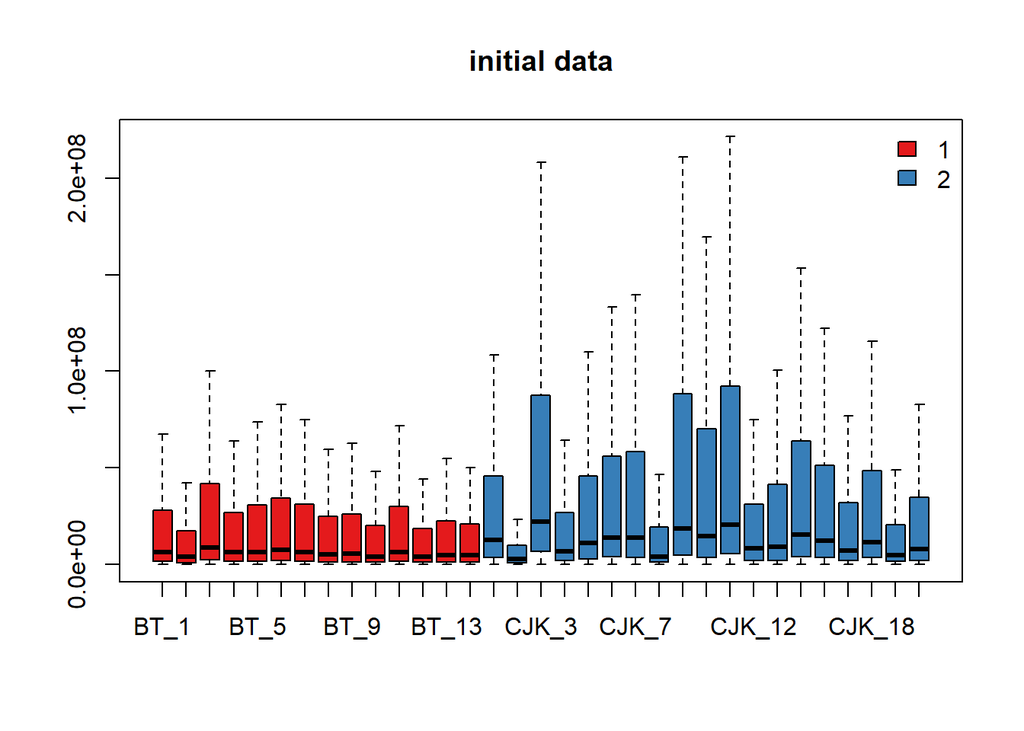

After initial clearing of data we can perform normalization

```r
df_log <- log2(knn_df+1)
df_norm <- normalizeQuantiles(as.matrix(df_log))
```

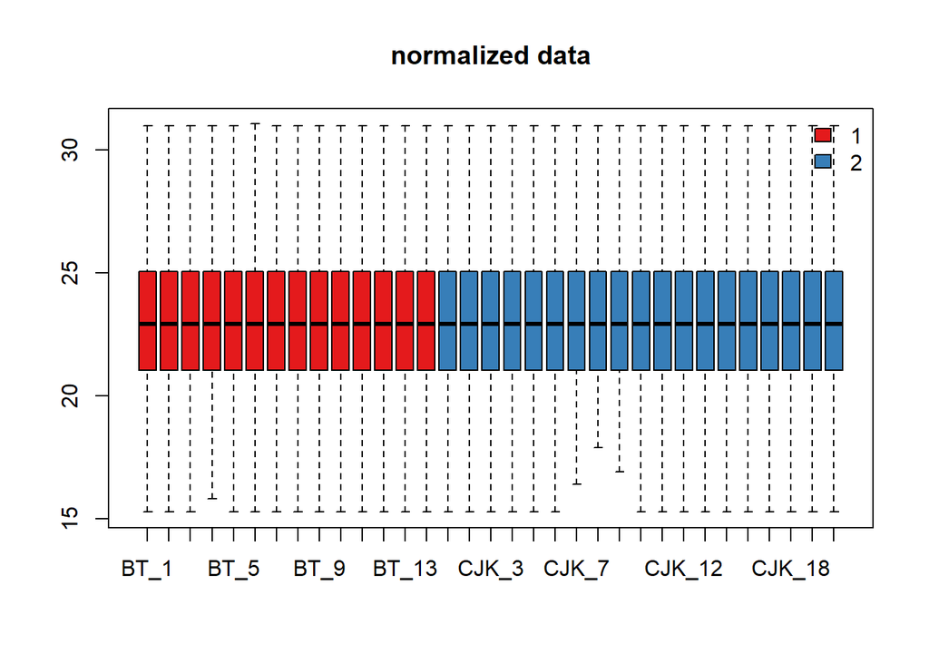

# Evaluation of the presence of a batch-effect

Lets perform PCA plot to look at clusters

```r
pca <- t(df_norm)
terapod_pca <- rda(pca, scale = TRUE)

rownames(pca) <- c("1","1","1","1","1","1","1","1","1","1","1","1","1","1","2","2","2","2","2","2","2","2","2","2","2","2","2","2","2","2","2","2","2")

df_scores <- data.frame(pca,
                        scores(terapod_pca, display = "sites", choices = c(1, 2, 3), scaling = "sites"))
```

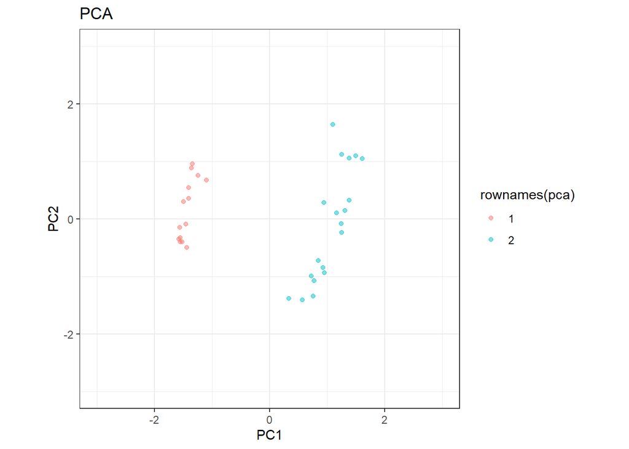

As we can see clusters looks as usual

Lets draw maplot

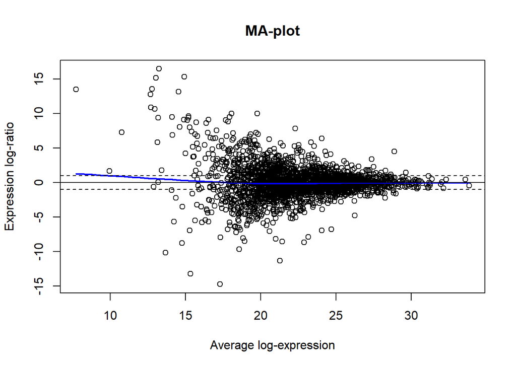

# Identification of differentially expressed proteins

Lets perform differential expression

```r
# Данные экспрессии
expr_data <- as.matrix(df_norm)

# Данные о пробах
pheno_data <- data.frame(experiment)
rownames(pheno_data) <- colnames(df_norm)
pheno_metadata <- data.frame(
  labelDescription = c("Experimental condition"),
  row.names=c("Condition"))
pheno_data <- new("AnnotatedDataFrame",
                 data = pheno_data,
                 varMetadata = pheno_metadata)

# Данные о признаках (белках)
feature_data <- data.frame(Prot = rownames(expr_data))
rownames(feature_data) <- rownames(expr_data)
feature_metadata <- data.frame(
  labelDescription = c("Protain name"),
  row.names = c("Protain"))
f_data <- new("AnnotatedDataFrame",
              data = feature_data,
              varMetadata = feature_metadata)

# Собираем вместе
exp_set <-
  ExpressionSet(assayData = expr_data,
                phenoData = pheno_data,
                featureData = f_data)
```

fit linear model for each gene given a series of arrays, compute moderated t-statistics, moderated F-statistic, and log-odds of differential expression by empirical Bayes moderation of the standard errors towards a global value

```r
X <- model.matrix(~ experiment, pData(exp_set))
fit <- lmFit(exp_set, design = X, method = "robust", maxit = 1000)
efit <- eBayes(fit)
```

draw new MA plot

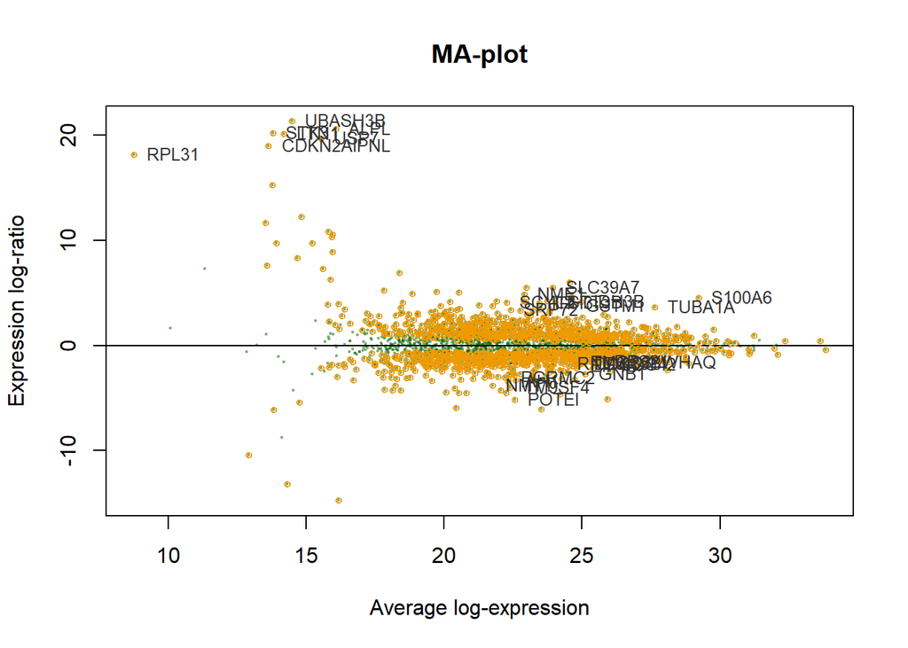

and show up and down regulated genes

```r
# ## Добываем дифференциально-экспрессируемые белки для дальнейшей работы =======
# Первые 20 дифференциальных белков
my_list <- topTable(efit, coef = 2, n = 100)
# Фильтруем ExpressionSet
dif_exp_set <- exp_set[fData(exp_set)$Prot %in% my_list$Prot, ]
```

Heatmap

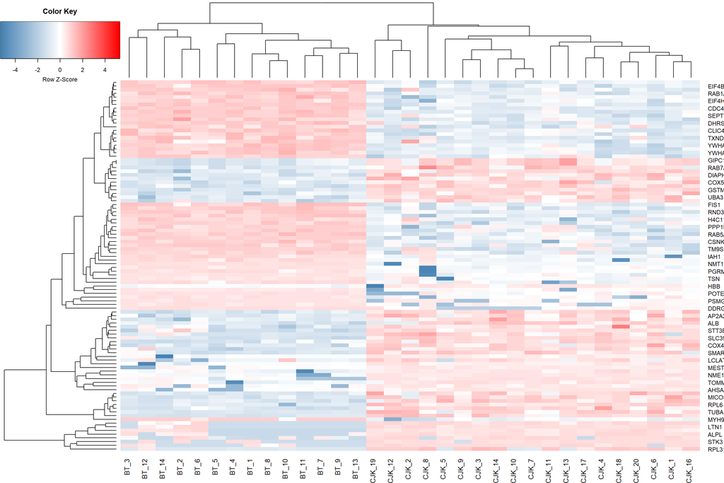

EnhancedVolcano plot

```r
topTable(efit, coef = 2)
```

```
##                  Prot     logFC   AveExpr         t      P.Value    adj.P.Val
## LTN1             LTN1 20.148712 14.198892  88.74374 5.916988e-41 1.336648e-37
## STK3             STK3 20.204647 13.810748  84.87205 2.574907e-40 2.908357e-37
## RPL31           RPL31 18.141070  8.759179  78.78637 2.988485e-39 2.250329e-36
## UBASH3B       UBASH3B 21.331004 14.485100  73.44482 3.015141e-38 1.702801e-35
## CDKN2AIPNL CDKN2AIPNL 18.991652 13.643165  37.16931 1.409333e-28 6.367365e-26
## USP7             USP7 19.697602 15.546024  28.47958 7.309194e-25 2.751912e-22
## TM9SF4         TM9SF4 -4.032617 22.404786 -26.82645 4.886121e-24 1.576821e-21
## NME1             NME1  4.857034 22.897614  26.68529 5.775122e-24 1.630750e-21
## GSTM1           GSTM1  3.769110 24.665788  24.91646 5.037392e-23 1.264385e-20
## ALPL             ALPL 20.576578 16.082899  21.13566 8.548918e-21 1.931201e-18
##                   B
## LTN1       74.95105
## STK3       74.59120
## RPL31      72.29128
## UBASH3B    71.54447
## CDKN2AIPNL 54.19347
## USP7       46.37538
## TM9SF4     44.59482
## NME1       44.49583
## GSTM1      42.42369
## ALPL       37.38384
```

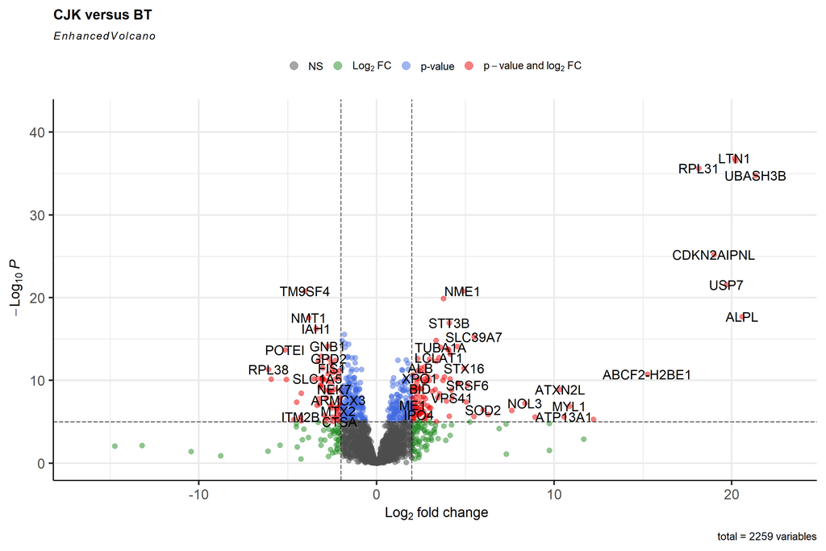

```r
numGenes <- nrow(exprs(exp_set))
res = topTable(efit, number = numGenes)

EnhancedVolcano(res,
                lab = rownames(res),
                x = 'logFC',
                y = 'adj.P.Val',
                title = 'CJK versus BT',
                FCcutoff = 2,
                pointSize = 3.0,
                labSize = 6.0)
```

# Enrichment

## Up-regulated genes

```r
genes_up = res$Prot[(res$logFC>2 & res$adj.P.Val<0.05)]

GO_enrich <- enrichGO(genes_up, "org.Hs.eg.db", keyType = "SYMBOL", ont = "BP")
```

```
##                    ID                                       Description
## GO:0090150 GO:0090150 establishment of protein localization to membrane
## GO:1990748 GO:1990748                           cellular detoxification
## GO:0097237 GO:0097237              cellular response to toxic substance
## GO:0009636 GO:0009636                       response to toxic substance
## GO:0098869 GO:0098869                   cellular oxidant detoxification
## GO:0016137 GO:0016137                       glycoside metabolic process
##            GeneRatio   BgRatio       pvalue   p.adjust     qvalue
## GO:0090150    12/170 280/18870 9.193514e-06 0.01424758 0.01303096
## GO:1990748     8/170 119/18870 1.234698e-05 0.01424758 0.01303096
## GO:0097237     8/170 128/18870 2.101827e-05 0.01424758 0.01303096
## GO:0009636    11/170 258/18870 2.295822e-05 0.01424758 0.01303096
## GO:0098869     7/170  99/18870 3.158897e-05 0.01424758 0.01303096
## GO:0016137     4/170  21/18870 3.376204e-05 0.01424758 0.01303096
##                                                                               geneID
## GO:0090150 SRP72/SEC61A1/TOMM40/SDCBP/BID/BAX/CEMIP/ATP13A1/SGTA/CCDC47/ACSL3/SAMM50
## GO:1990748                                    GSTM1/ALB/HBB/PXDN/SOD2/MGST1/GPX1/TXN
## GO:0097237                                    GSTM1/ALB/HBB/PXDN/SOD2/MGST1/GPX1/TXN
## GO:0009636                     GSTM1/ALB/HBB/PXDN/BAX/SOD2/CES1/MGST1/EPHX1/GPX1/TXN
## GO:0098869                                          ALB/HBB/PXDN/SOD2/MGST1/GPX1/TXN
## GO:0016137                                                AKR1C2/FUCA2/AKR1B1/AKR7A2
##            Count
## GO:0090150    12
## GO:1990748     8
## GO:0097237     8
## GO:0009636    11
## GO:0098869     7
## GO:0016137     4
```

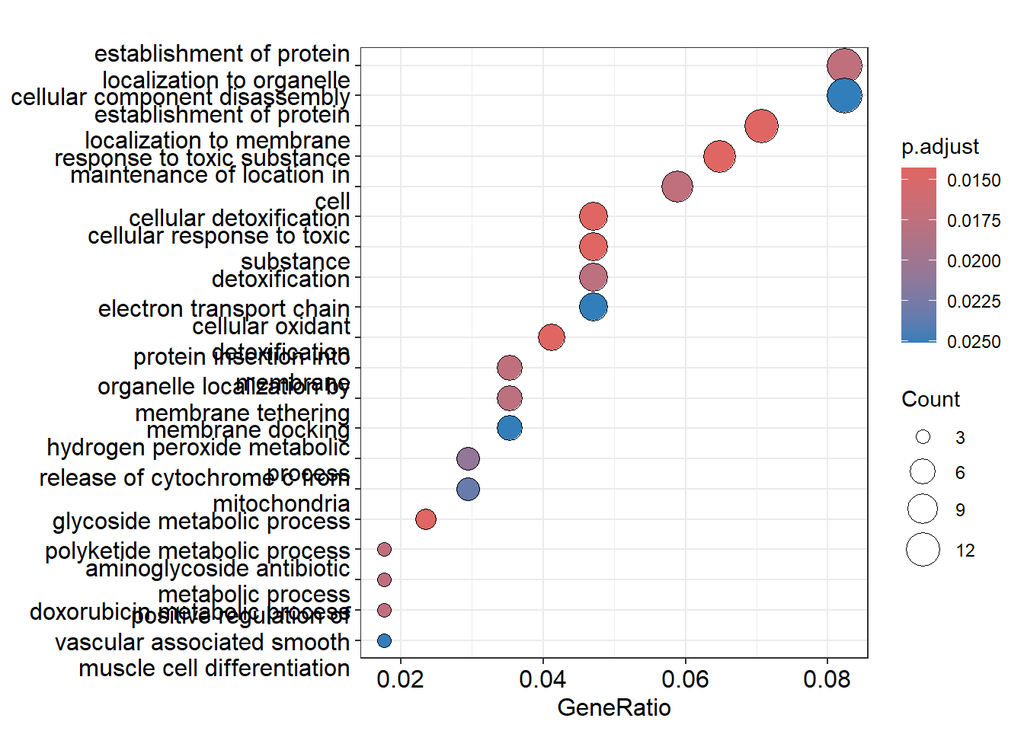

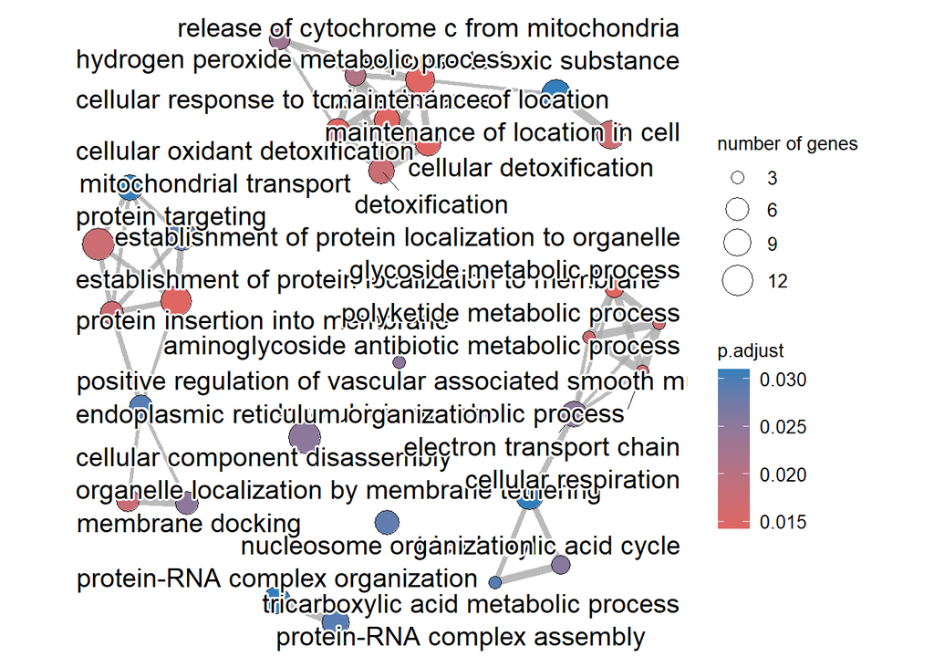

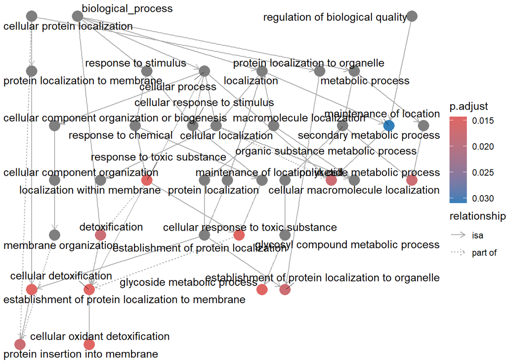

```r
genes_down = res$Prot[(res$logFC<2 & res$adj.P.Val<0.05)]

GO_enrich <- enrichGO(genes_down, "org.Hs.eg.db", keyType = "SYMBOL", ont = "BP")
```

```
##                    ID                                        Description
## GO:0002181 GO:0002181                            cytoplasmic translation
## GO:0048193 GO:0048193                            Golgi vesicle transport
## GO:0006457 GO:0006457                                    protein folding
## GO:0016050 GO:0016050                               vesicle organization
## GO:0006413 GO:0006413                           translational initiation
## GO:0072594 GO:0072594 establishment of protein localization to organelle
##            GeneRatio   BgRatio       pvalue     p.adjust       qvalue
## GO:0002181   58/1140 156/18870 5.619384e-31 2.909155e-27 2.360733e-27
## GO:0048193   67/1140 294/18870 1.176008e-21 3.044097e-18 2.470236e-18
## GO:0006457   56/1140 223/18870 2.058957e-20 3.553074e-17 2.883263e-17
## GO:0016050   69/1140 366/18870 1.637173e-17 2.118911e-14 1.719462e-14
## GO:0006413   37/1140 123/18870 1.068104e-16 1.105915e-13 8.974325e-14
## GO:0072594   77/1140 459/18870 2.122858e-16 1.831673e-13 1.486373e-13
##                                                                                                                                                                                                                                                                                                          …
## GO:0002181                                                                                                                        RPS21/RPL6/RPL38/EIF3A/RPL10/RPS14/RPS2/SYNCRIP/RPS3A/PABPC1…
## GO:0048193                                                   RAB1A/HYOU1/COPE/VAMP2/SEC24D/RAB1B/ARF4/RAB31/TMED10/SEC16A…
## GO:0006457                                                                                                                                  CANX/TXNDC5/HYOU1/TBCE/PPIA/DNAJB11/ERP44/FKBP9/PPIB/BAG2/CD…
## GO:0016050      RAB1A/RAB7A/VAMP2/SEC24D/VPS4B/PI4K2A/STAM2/TSG101/AP2M1/TME…
## GO:0006413                                                                                                                                                                                                                                           EIF4B/EIF4H/EIF3A/RPS3A/EIF6/EIF3I/BZW1/EIF3J/EIF5B/…
## GO:0072594 NMT1/FIS1/AIFM1/RAB7A/MGARP/KPNB1/NUP155/KPNA3/MTCH2/H1-5/STAM2/RPL23/TSG101/CCT5/MTX2/AP3D1/KPNA1/TRIM28/AP3B1/TIMM…
##            Count
## GO:0002181    58
## GO:0048193    67
## GO:0006457    56
## GO:0016050    69
## GO:0006413    37
## GO:0072594    77
```

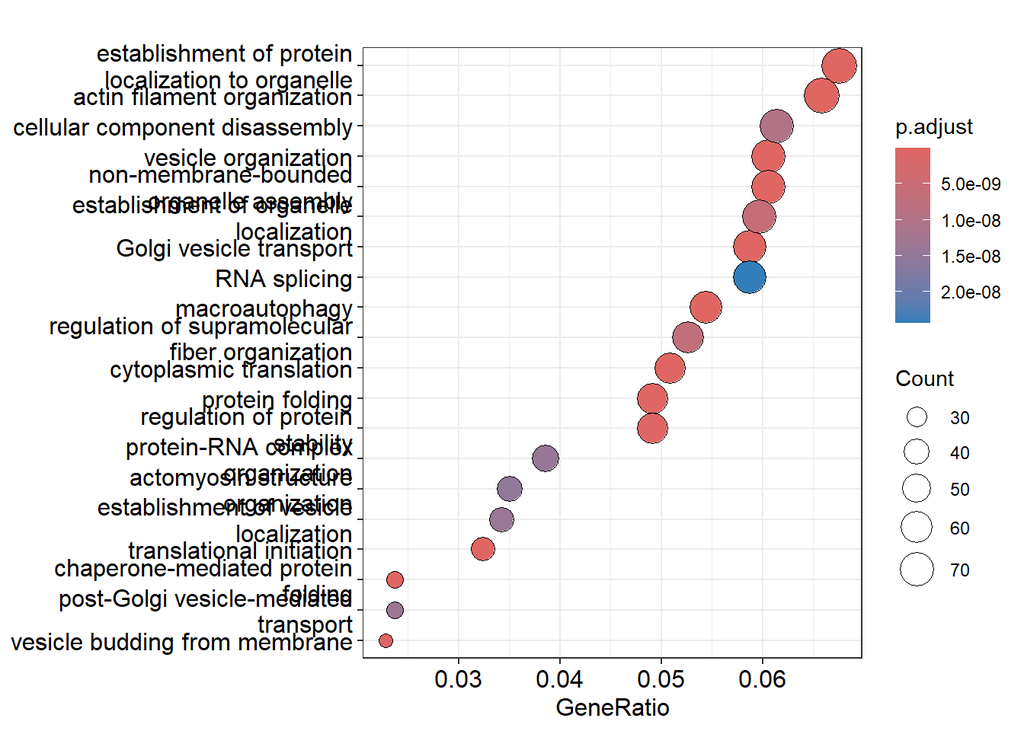

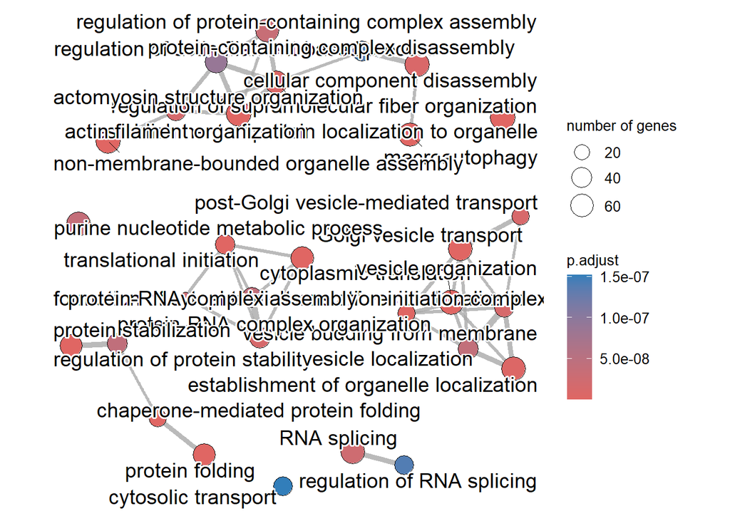

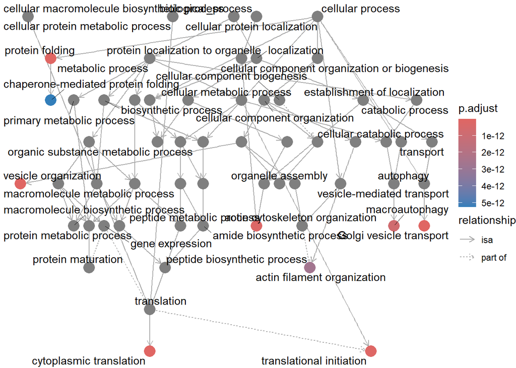

Тhe GO-enrichment analysis suggests that the myocardium in CJK patients is facing challenges related to toxic substance response, doxorubicin metabolism, and disruptions in essential cellular processes. These molecular disturbances could be contributing factors to the cardiac dysfunction and structural changes observed in these patients.